# Math&146 Lab #6

N. Paterno

For this lab, we’ll once again be using the *speed_gender_height* data set from the *openintro* package. This time we’ll learn how to use *R* to calculate probabilities for data that has a normal distribution.

## Clean the Data

As before, we’ll remove all observations that are missing a value for one of the variables.

```r
plot_data <- speed_gender_height %>%
  na.omit()
```

## Confirm Shape

Before we start calculating probabilities, we’ll need to plot our data and confirm the distribution is normal (this was the assignment from the previous lab).

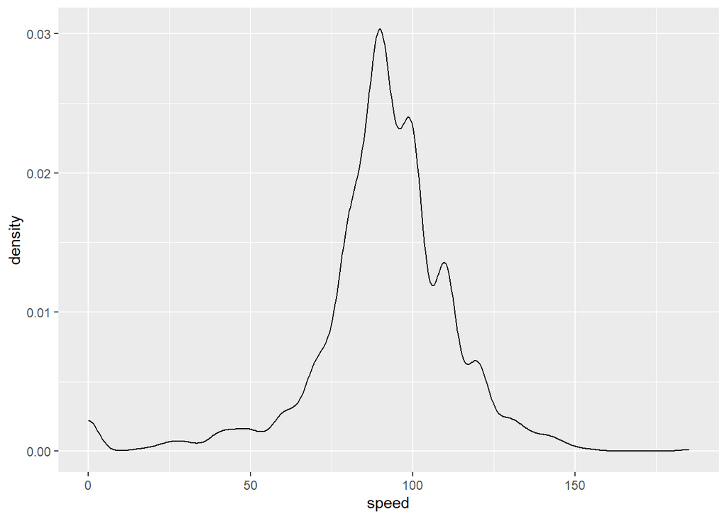

```r
ggplot(plot_data,
       aes(speed))+
  geom_density()
```

As expected, the distribution is normal.

## Calculating Probabilities

To calculate probabilities, we’ll use the *pnorm* function from the *stats* package. We don’t need to load the *stats* package separately as its included in the base set for *R*.

Since we’ll be using them repeatedly, our code will be more efficient if we define variables for the mean and standard deviation.

```r
mean_speed <-  mean(plot_data$speed)
sd_speed <- sd(plot_data$speed)
```

First, we’ll calculate the probability of randomly selecting an individual who has driven more than 100 miles per hour, $P(X>100)$.

```r
pnorm(100, # x value for probability
      mean = mean_speed, # mean of the variable
      sd = sd_speed, # standard deviation of the variable
      lower.tail = FALSE) # specifices if the probability is < (TRUE) or > (FALSE)
```

```
## [1] 0.3402052
```

According to our data, the probability of selecting a person who has driven more than 100 mph is just north of 34%.

The syntax for the input to the pnorm function is commented in the above code.

Next, we’ll calculate $P(x<60)$.

```r
pnorm(60,
      mean_speed,
      sd_speed,
      lower.tail = TRUE)
```

```
## [1] 0.08541816
```

The probability of randomly selecting someone who has driven no faster than 60 mph is 8.54%.

What about a probability for between two values? $P(60<x<70)$

```r
pnorm(70,
      mean_speed,
      sd_speed,
      lower.tail = TRUE)-
  pnorm(60,
      mean_speed,
      sd_speed,
      lower.tail = TRUE)
```

```
## [1] 0.09228196
```

There is a 9.23% chance of selecting someone who has driven at most, somewhere between 60 and 70 mph.

## Assignment

In a script file:

1. Clean the data to remove any observations that have missing values and filter to a single gender.
2. Recalculate the above probabilities with this new data frame.
3. Does the gender you chose appear to have different probabilities than the general population?

Save your work in a script file called: LastName_lab6. For example, my assignment file would be Paterno_lab6.R